# Task: bodyfat prediction

- Show All Code
- Hide All Code
- View Source

2024

Contrast-Bayes-Frequentist

STRATOS

R

Classification: confidential

Author

Affiliation

Georg Heinze

Medical University of Vienna, Center for Medical Data Science

Published

June 13, 2025

## 1 Data sets

Two data sets are available. The first is a data set published by [Johnson (2021)](https://doi.org/10.1080/26939169.2021.1971585) contains body fat proportion and anthropometric measures of 184 women aged 18-25. The second data set was published by [Johnson (1996)[http://jse.amstat.org/v4n1/datasets.johnson.html] and contains similar data of 252 men aged 22-81.

### 1.1 Data set of college women

The data set of 184 college women can be downloaded from the journal website and is contained in this repository. The data set description is contained in a separate text file that is reproduced here:

NAME: BodyFatInfo.txt

SIZE: 184 observations, 20 variables

ARTICLE TITLE: Fitting Percentage of Body Fat to Simple Body Measurements: College Women

DESCRIPTIVE ABSTRACT:

Percentage of body fat, age, weight, height, body mass index and fourteen circumference measurements are given for 184 college women ages 18-25. Body fat was accurately determined by an underwater weighing technique which requires special equipment and training of the individuals conducting the process. Circumference measurements were made to the nearest 0.1 cm using a cloth tape in complete contact with the skin but without compression of the soft tissues. The measurement process, described somewhat incompletely below, is described in greater detail in Slack (1997) who used the standards recommended by Lohman, Roche and Martrell (1988).

SOURCES:

- Lohman, T.G., Roche, A.F., Martorell, R. (1988), Anthropometric Standardization Reference Manual, Champaign, IL: Human Kinetics Books.
- Siri, W.E. (1956), Gross Composition of the Body, in Advances in Biological and Medical Physics (vol. IV), editors J.H. Lawrence and C.A. Tobias, New York: Academic Press.
- Slack, Jason V. (1997), Estimating Body Fat Percentage Using Circumference Measurements and Lifestyle Questionnaire Data: A Multivariate Study of 184 College Aged Females, M.S. Thesis, Department of Physical Education, Brigham Young University. An electronic copy of this thesis is available via OregonPDF in Health & Performance, https://www.oregonpdf.org/, Catalog ID: PE 3794.

VARIABLE DESCRIPTIONS:

- Obs: Observation number, 1-184
- Fat: Amount of body fat expressed as a percentage of total body weight, using Siri’s (1956) method
- Weight (kg)
- Height (m)
- BMI: (Body Mass Index) Weight divided by the square of Height
- Age
- Neck: Minimal circumference perpendicular to the long axis of the neck (cm)
- Chest: Horizontal plane measurement at the sixth rib, at the end of a normal expiration (cm)
- Calf: Horizontal maximal calf measurement (cm)
- Biceps: Measurement with arm extended (cm)
- Hips: Horizontal maximal measurement around buttocks (cm)
- Waist: Horizontal minimal measurement, at the end of a normal expiration (cm)
- Forearm: Maximal measurement perpendicular to long axis (cm)
- PThigh: (Proximal Thigh) Horizontal measurement immediately distal to the gluteal furrow (cm)
- MThigh: (Middle Thigh) Measurement midway between the midpoint of the inguinal crease and the proximal border of the patella (cm)
- DThigh: (Distal Thigh) Measurement proximal to the femoral epicondyles (cm)
- Wrist: Measurement perpendicular to the long axis of the forearm (cm)
- Knee: Measurement at the mid-patellar level, with the knee slightly flexed (cm)
- Elbow: A minimal circumference measurement with the elbow extended (cm)
- Ankle: Minimal circumference measurement perpendicular to the long axis of the calf (cm)

STORY BEHIND THE DATA:

Please see the JSE Datasets article.

PEDAGOGICAL NOTES: The dataset may be used to illustrate the various components of building a predictive model for percent body fat. While the number of cases is fairly modest, the dataset is fairly rich in terms of the number of potential predictor variables.

SUBMITTED BY: Roger W. Johnson Department of Mathematics South Dakota School of Mines & Technology 501 East St. Joseph Street Rapid City, South Dakota 57701 roger.johnson@sdsmt.edu

The variable `Fat` corresponds to the Siri formula of estimating body fat proportion in percent.

```r
women <- read.table("Datafiles/Bodyfat.txt", header=TRUE)
```

The following data corrections are applied:

[output not shown]

These data points are set to the respective medians.

```r
women$Age[women$Age==1] <- median(women$Age)
women$Chest[women$Chest<60] <- median(women$Chest)
women$Calf[women$Calf==66] <- median(women$Calf)
women$Knee[women$Knee==24.7] <- median(women$Knee)
women$Elbow[women$Elbow==15.5] <- median(women$Elbow)
```

### 1.2 Data set of men

The data set can be assessed via the R package `mfp`:

```r
library(mfp)
data(bodyfat)
```

In the paper by Johnson (1996), a few corrections to the data were described. We performed them below. Moreover, we recompute the percentage of body fat given both the Siri formula (BF% = 495/density - 450) and the Brozek formula (BF% = 457/density - 414.2), rounded up to one decimal place. We also set any values lower than 0 to 0 according to Johnson (1996). Note that these recomputed values differ compared to the published ones in 33 and 43 observations, respectively.

```r
bodyfat_corr <- bodyfat

bodyfat_corr[42,"height"] <- 69.5       # one-digit correction of height
bodyfat_corr[48,"density"] <- 1.0865    # one-digit correction of density
bodyfat_corr[76,"density"] <- 1.0566    # one-digit correction of density
bodyfat_corr[96,"density"] <- 1.0591    # one-digit correction of density

# recompute siri formula based on corrected density

bodyfat_corr[,"siri"]   <- pmax(round(495 / bodyfat_corr$density - 450, 1) , 0)
bodyfat_corr[,"brozek"] <- pmax(round(457/ bodyfat_corr$density - 414.2, 1) , 0)
```

### 1.3 Aligning the two data sets

Now we transform the measurements of height and weight in `men` into m and kg for better comparability with the `women` data set.

```r
bodyfat_corr$height <- bodyfat_corr$height * 2.54/100
bodyfat_corr$weight <- bodyfat_corr$weight * 0.454592
```

```r
library(tidyverse)
# We now compute the BMI for the men:

bodyfat_corr$BMI <- bodyfat_corr$weight / bodyfat_corr$height^2

# we will assign 'thigh' variable to 'MThigh' to align with the women data set.

men <- bodyfat_corr %>%
  rename(Fat = siri, Age = age, Height = height, Weight = weight, Neck = neck, Chest = chest, Waist = abdomen, Hips = hip, Knee = knee, Ankle = ankle, Wrist = wrist, Forearm = forearm, Biceps = biceps, MThigh = thigh, BMI = BMI)
```

## 2 Task description

*Training set:* For the task, the `women` data set should be used as training set to develop a prediction model of body fat percentage. The prediction model should contain no more than 5 predictors (originally measured anthopometrics including age and weight), but can have fewer predictors. In the final formula, the predictors should have linear functional forms.

*Test set:* The `men` data set should be used to provide an estimate of the model’s performance in terms of root mean squared prediction error (RMSPE, root mean squared difference of predicted and measured body fat percentage), R-squared (one minus sum of squared deviation of observed from predicted bodyfat percentage divided by sum of squared deviations of observed bodyfat from mean bodyfat in the test set), calibration slope (slope of regression line of observed regressed on predicted body fat percentage) and calibration intercept (intercept of regression of observed on predicted body fat percentage with the slope fixed to 1). *These measures can be accompanied by appropriate uncertainty intervals.*

The goal is to find a 5-predictor model and to test its performance in the men data set.

## 3 Save data sets

```r
save(list=c("men", "women"), file="Datafiles/bodyfatdata.Rdata")
```

## 4 Initial data analysis

Here we provide insight into the distributions of all variables, and the joint distribution of the predictors in each of training (women) and test (men) sets.

### 4.1 Predictor distributions

```r
require(ggplot2)

#helper function to compare distributions between women and men

compare_histograms <- function(men, women, varname, bins = 30, xlab = NULL, title = NULL) {
  # Determine availability of the variable in each dataset
  has_men_var <- varname %in% names(men)
  has_women_var <- varname %in% names(women)

  # Handle case: variable missing from both datasets
  if (!has_men_var && !has_women_var) {
    stop(paste("Variable", varname, "not found in either 'men' or 'women' data frame."))
  }

  # Extract data from available datasets
  data_list <- list()
  if (has_men_var) {
    data_list[[length(data_list) + 1]] <- data.frame(
      value = men[[varname]],
      group = "Men"
    )
  }
  if (has_women_var) {
    data_list[[length(data_list) + 1]] <- data.frame(
      value = women[[varname]],
      group = "Women"
    )
  }

  combined_df <- do.call(rbind, data_list)

  # Set default axis label and title if not provided
  if (is.null(xlab)) xlab <- varname
  if (is.null(title)) {
    title <- paste("Histogram of", varname,
                   if (has_men_var && has_women_var) "by Sex"
                   else if (has_men_var) "for Men"
                   else "for Women")
  }

  # Plot using ggplot2
   ggplot(combined_df, aes(x = value, fill = group)) +
    geom_histogram(position = "identity", alpha = 0.5, bins = bins) +
    labs(title = title, x = xlab, y = "Count") +
    scale_fill_manual(values = c("Men" = "steelblue", "Women" = "tomato")) +
    theme_minimal()
}
```

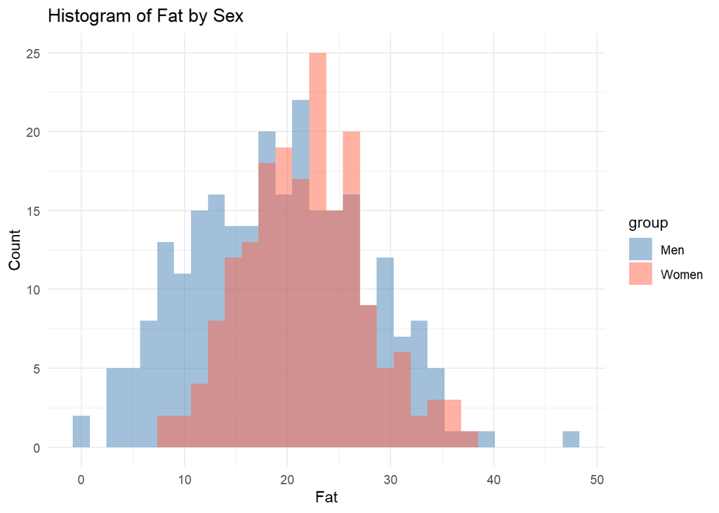

```r
compare_histograms(men, women, "Fat")
```

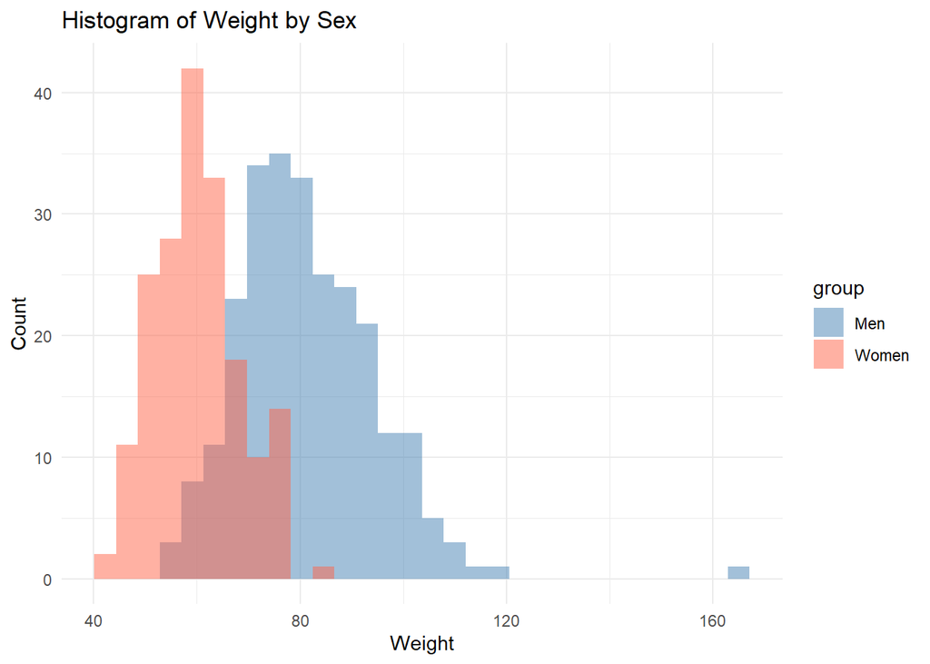

```r
compare_histograms(men, women, "Weight")
```

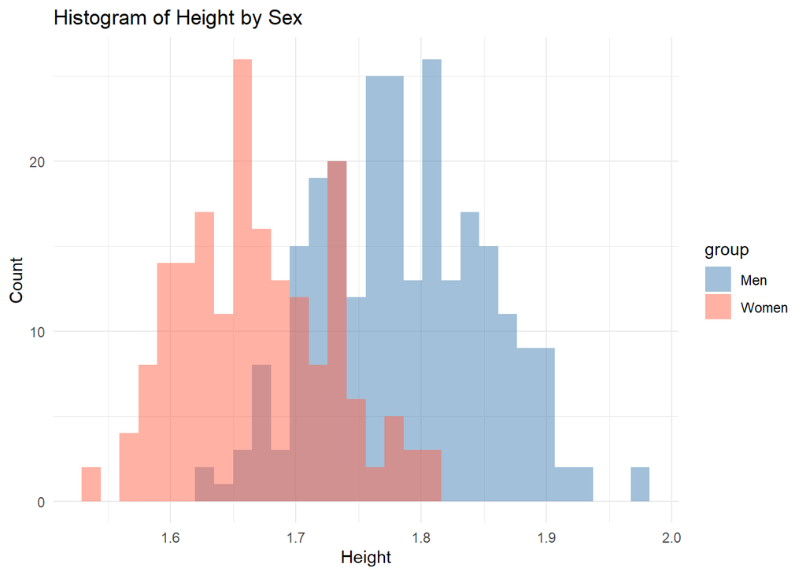

```r
compare_histograms(men, women, "Height")
```

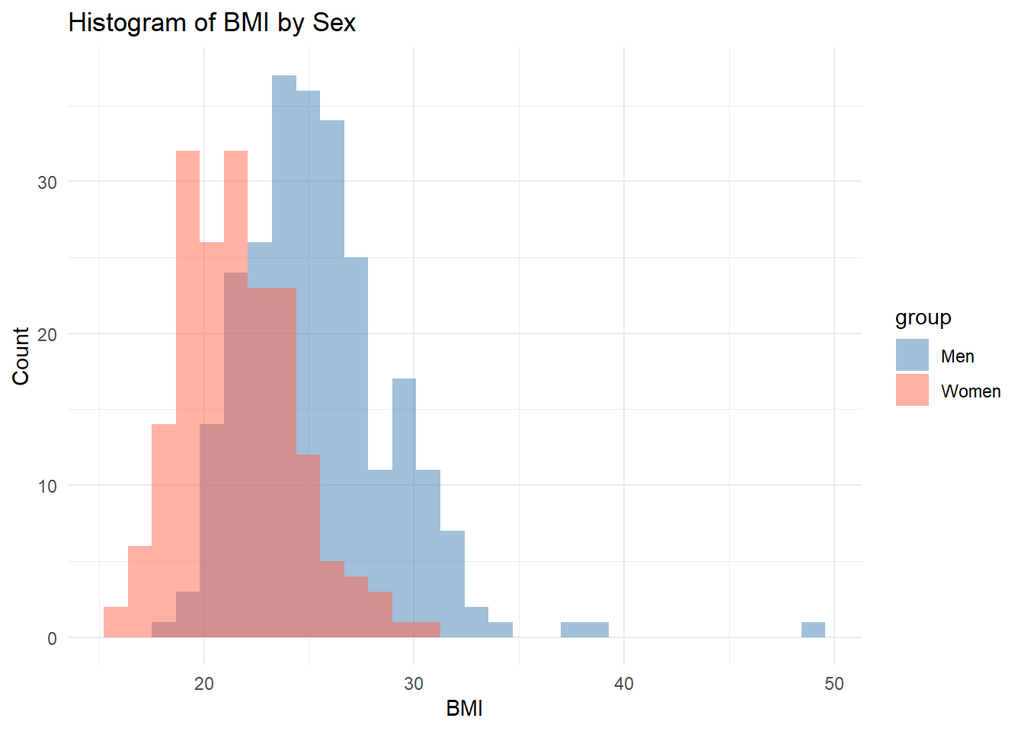

```r
compare_histograms(men, women, "BMI")
```

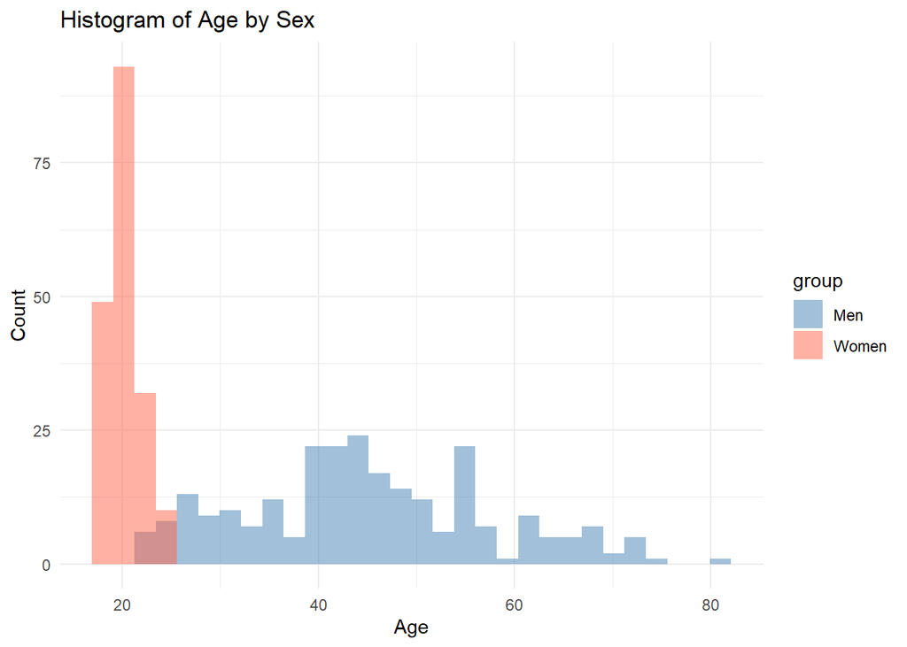

```r
compare_histograms(men, women, "Age")
```

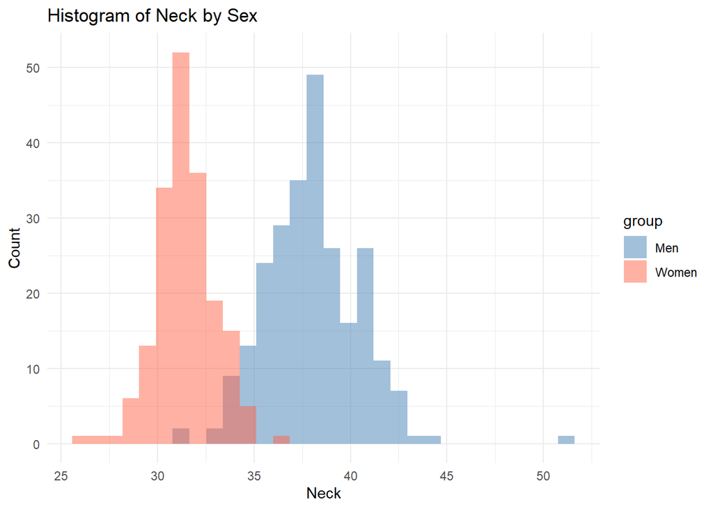

```r
compare_histograms(men, women, "Neck")
```

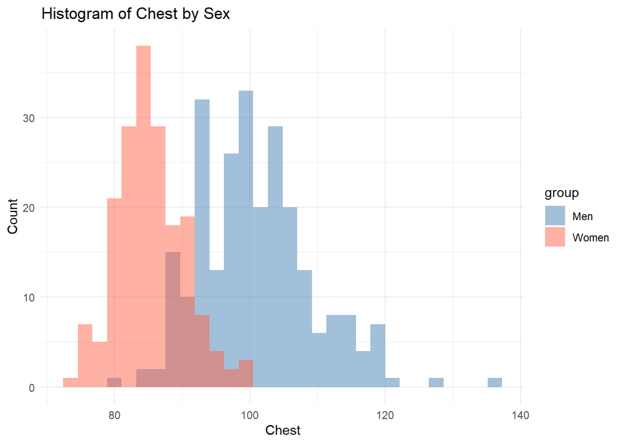

```r
compare_histograms(men, women, "Chest")
```

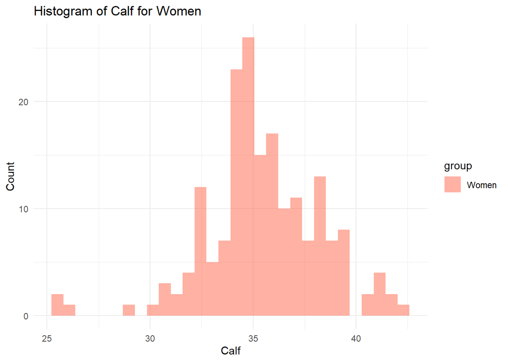

```r
compare_histograms(men, women, "Calf") # only available for women!
```

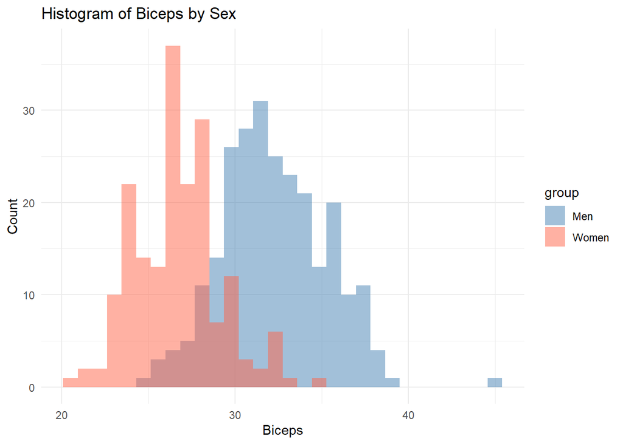

```r
compare_histograms(men, women, "Biceps")
```

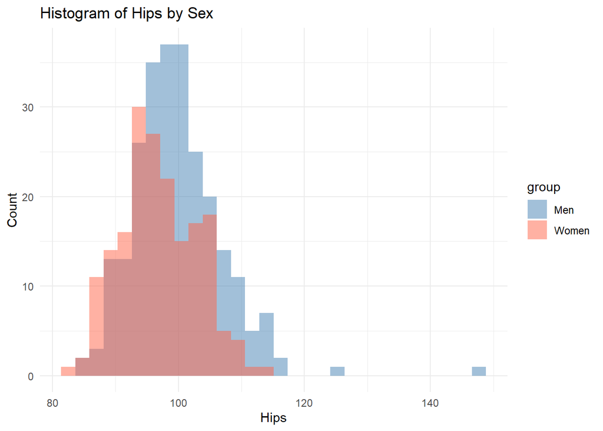

```r
compare_histograms(men, women, "Hips")
```

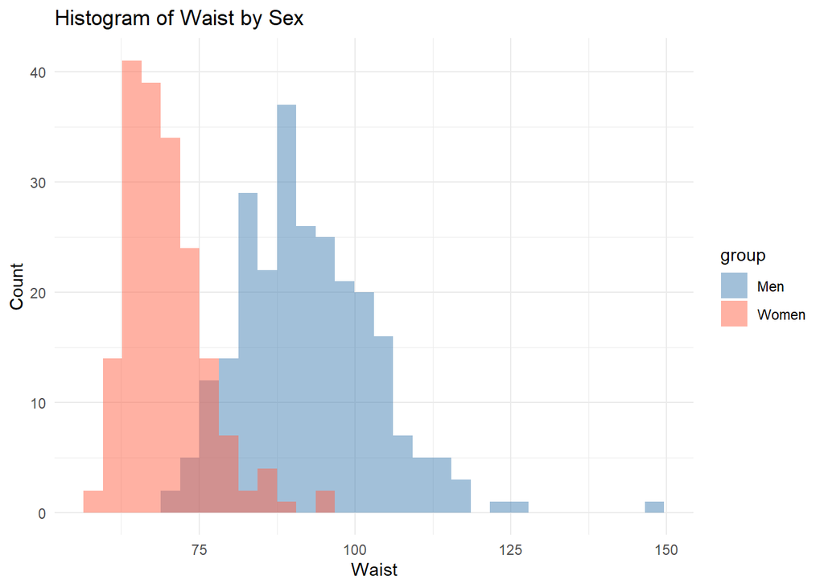

```r
compare_histograms(men, women, "Waist")
```

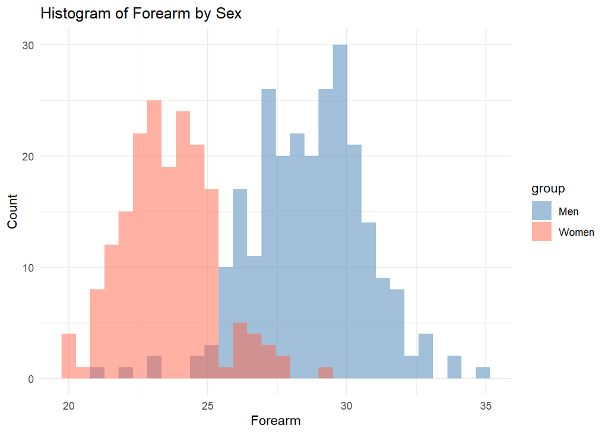

```r
compare_histograms(men, women, "Forearm")
```

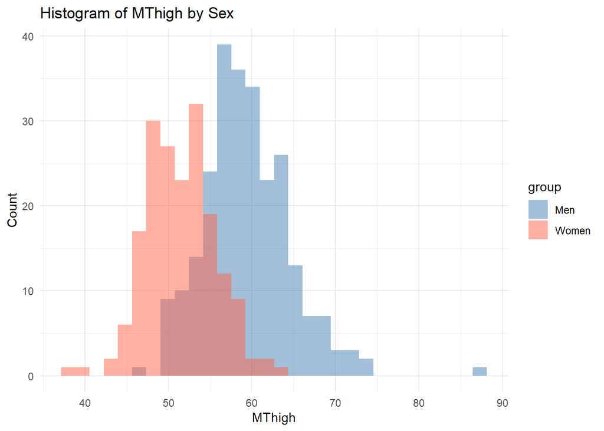

```r
compare_histograms(men, women, "MThigh")
```

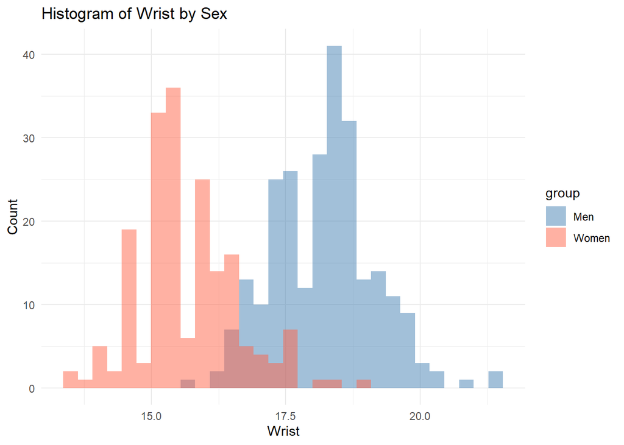

```r
compare_histograms(men, women, "Wrist")
```

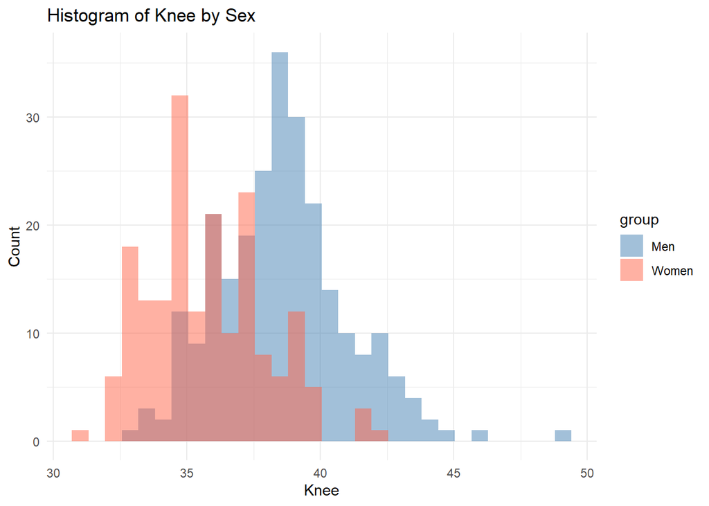

```r
compare_histograms(men, women, "Knee")
```

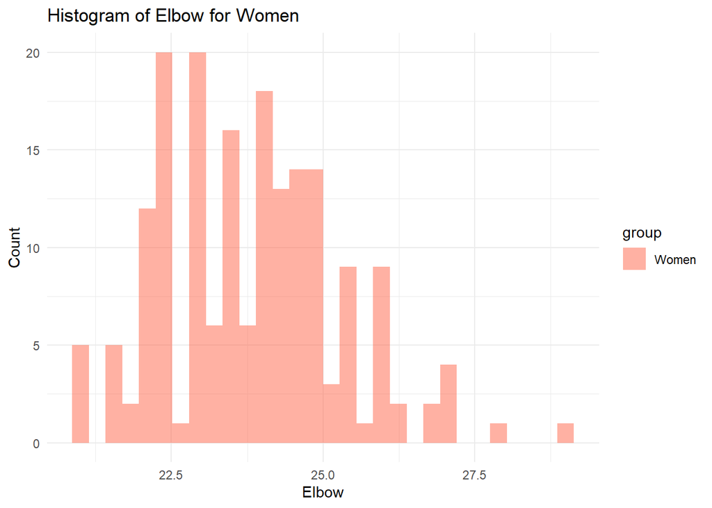

```r
compare_histograms(men, women, "Elbow") # only available for women!
```

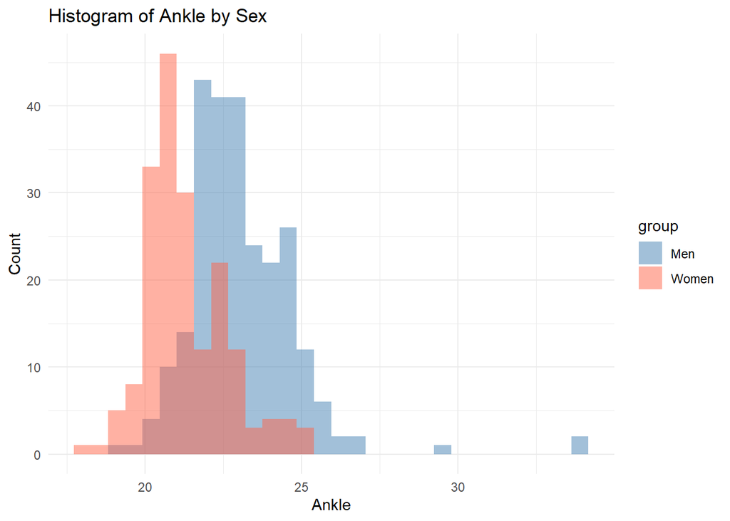

```r
compare_histograms(men, women, "Ankle")
```

The age distributions are strikingly different between the two data sets. The age range for women is between 18 and 25, while that for men is between 20 and 80.

The variable Calf and Elbow only exist for women; hence, to be able to validate the model in men, these variables should not be used for model building.

## 5 Correlation analysis

Next we compute Spearman correlations between the pairs of predictors. We depict the correlation using a network graph.

### 5.1 A helper function for network graphs

```r
# helper function for correlation network graph
# Load necessary libraries
correlation_network <- function(data, threshold = 0.3, title = "Spearman Correlation Network") {
  # Load required packages
  if (!requireNamespace("igraph", quietly = TRUE)) install.packages("igraph")
  if (!requireNamespace("Hmisc", quietly = TRUE)) install.packages("Hmisc")
  if (!requireNamespace("ggraph", quietly = TRUE)) install.packages("ggraph")
  if (!requireNamespace("tidygraph", quietly = TRUE)) install.packages("tidygraph")

  library(igraph)
  library(Hmisc)
  library(ggraph)
  library(tidygraph)

  # Use only numeric variables
  numeric_data <- data[sapply(data, is.numeric)]
  var_names <- colnames(numeric_data)

  # Compute Spearman correlations
  cor_res <- rcorr(as.matrix(numeric_data), type = "spearman")
  corr_mat <- cor_res$r

  # Remove diagonal and lower triangle (symmetric matrix)
  corr_mat[lower.tri(corr_mat, diag = TRUE)] <- NA

  # Convert to edge list and apply threshold
  edge_list <- as.data.frame(as.table(corr_mat), stringsAsFactors = FALSE)
  edge_list <- na.omit(edge_list)
  edge_list <- edge_list[abs(edge_list$Freq) >= threshold, ]
  names(edge_list) <- c("from", "to", "weight")

  # Create node data frame (all variables)
  node_df <- data.frame(name = var_names, stringsAsFactors = FALSE)

  # Create graph with full node list
  # Create graph with full node list
  g <- graph_from_data_frame(d = edge_list, vertices = node_df, directed = FALSE)

  # Edge attributes
  E(g)$weight_abs <- abs(E(g)$weight)
  E(g)$color <- ifelse(E(g)$weight > 0, "steelblue", "tomato")
  E(g)$distance <- 1 - E(g)$weight_abs  # correlation to distance

  # Compute average path length
  if (is.connected(g)) {
  avg_path_len <- average.path.length(g, weights = E(g)$distance)
  } else {
    comps <- components(g)
    largest_comp <- induced_subgraph(g, which(comps$membership == which.max(comps$csize)))
    avg_path_len <- average.path.length(largest_comp, weights = E(largest_comp)$distance)
  }
  cat("Average weighted path length (1 - |Spearman|):", round(avg_path_len, 3), "\n")
  # Layout with force-directed algorithm
  layout <- layout_with_fr(g, weights = E(g)$weight_abs)

  # Convert to tidygraph object
  g_tbl <- as_tbl_graph(g)

  # Plot with ggraph
  ggraph(g_tbl, layout = "manual", x = layout[,1], y = layout[,2]) +
    geom_edge_link(aes(width = weight_abs, color = weight), alpha = 0.8) +
    geom_node_point(size = 5, color = "grey30") +
    geom_node_text(aes(label = name), repel = TRUE) +
    scale_edge_color_gradient2(low = "tomato", mid = "grey80", high = "steelblue", midpoint = 0) +
    scale_edge_width(range = c(0.5, 2.5)) +
    labs(title = title, edge_color = "Spearman r") +
    theme_minimal()
}
```

In the following, we depict the network for varying thresholds (edges with correlation coefficients below the threshold are omitted):

```
Average weighted path length (1 - |Spearman|): 0.364
```

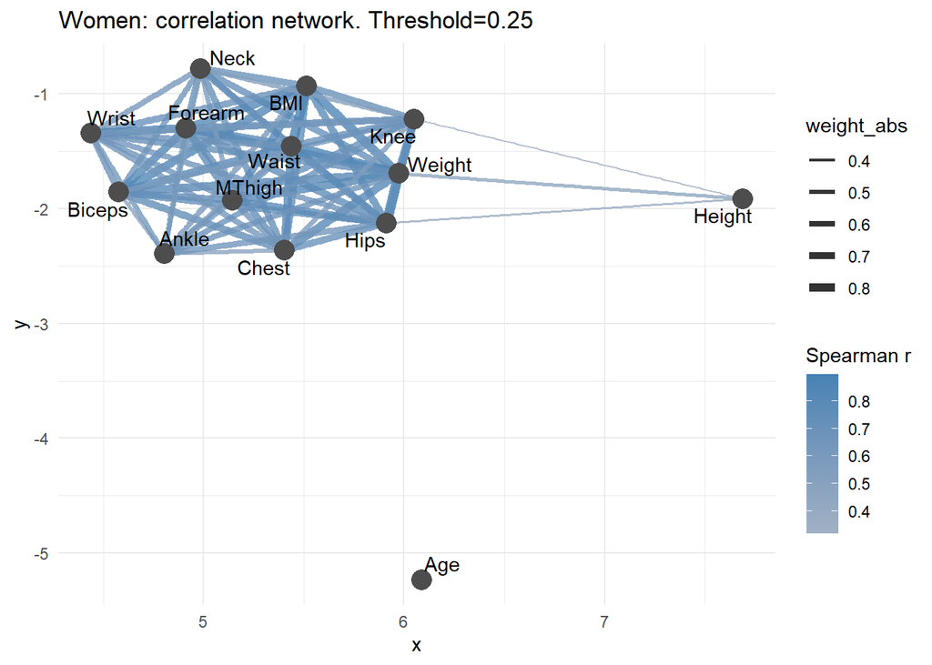

```r
correlation_network(women[,c("Weight", "Height", "BMI", "Age", "Neck", "Chest", "Biceps", "Hips", "Waist", "Forearm", "MThigh", "Wrist", "Knee", "Ankle")], threshold = 0.25, title = "Women: correlation network. Threshold=0.25")
```

```
Average weighted path length (1 - |Spearman|): 0.296
```

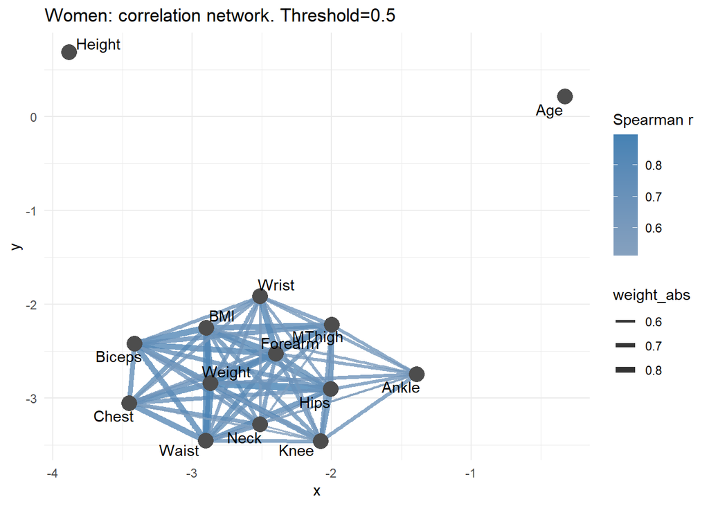

```r
correlation_network(women[,c("Weight", "Height", "BMI", "Age", "Neck", "Chest", "Biceps", "Hips", "Waist", "Forearm", "MThigh", "Wrist", "Knee", "Ankle")], threshold = 0.5, title = "Women: correlation network. Threshold=0.5")
```

```
Average weighted path length (1 - |Spearman|): 0.3
```

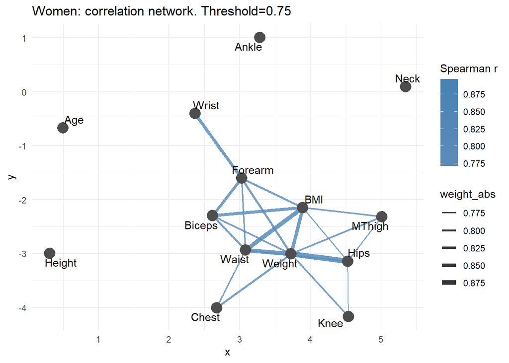

```r
correlation_network(women[,c("Weight", "Height", "BMI", "Age", "Neck", "Chest", "Biceps", "Hips", "Waist", "Forearm", "MThigh", "Wrist", "Knee", "Ankle")], threshold = 0.75, title = "Women: correlation network. Threshold=0.75")
```

We learn that the correlations in this data set are very strong. Only Age and Height are only weakly connected to the other nodes.

Now we repeat the same exercise for the men’s data set:

```
Average weighted path length (1 - |Spearman|): 0.33
```

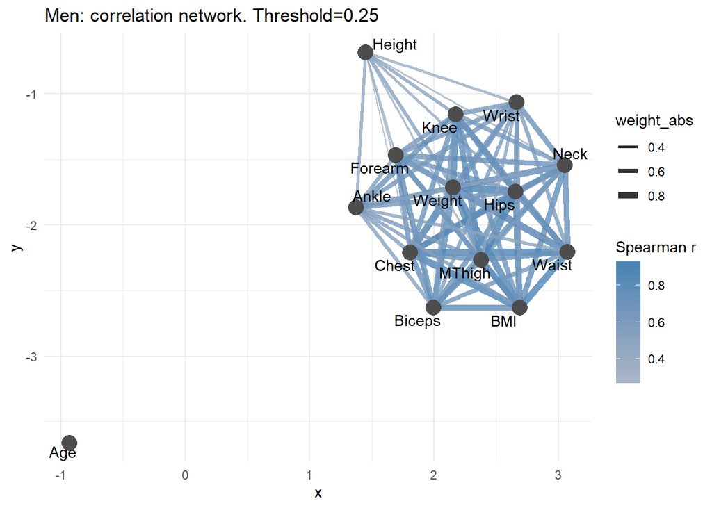

```r
correlation_network(men[,c("Weight", "Height", "BMI", "Age", "Neck", "Chest", "Biceps", "Hips", "Waist", "Forearm", "MThigh", "Wrist", "Knee", "Ankle")], threshold = 0.25, title = "Men: correlation network. Threshold=0.25")
```

```
Average weighted path length (1 - |Spearman|): 0.335
```

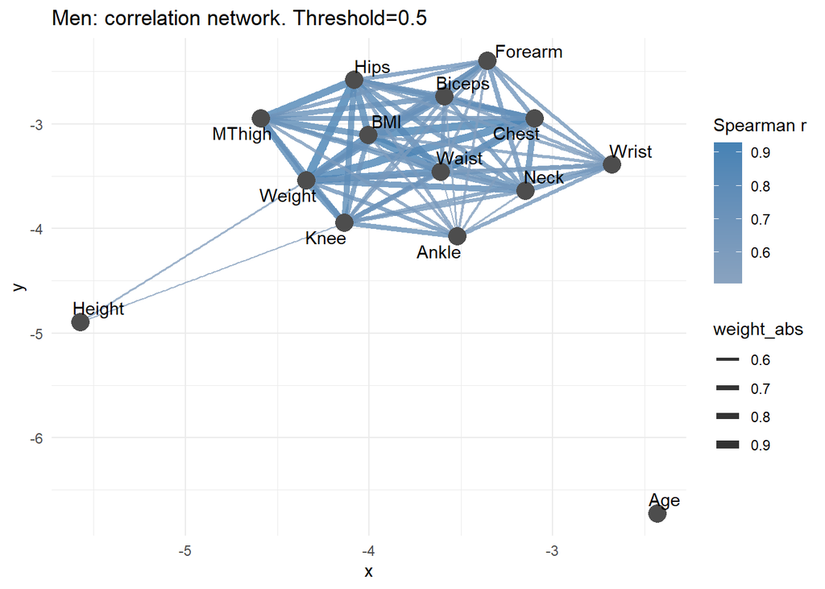

```r
correlation_network(men[,c("Weight", "Height", "BMI", "Age", "Neck", "Chest", "Biceps", "Hips", "Waist", "Forearm", "MThigh", "Wrist", "Knee", "Ankle")], threshold = 0.5, title = "Men: correlation network. Threshold=0.5")
```

```
Average weighted path length (1 - |Spearman|): 0.287
```

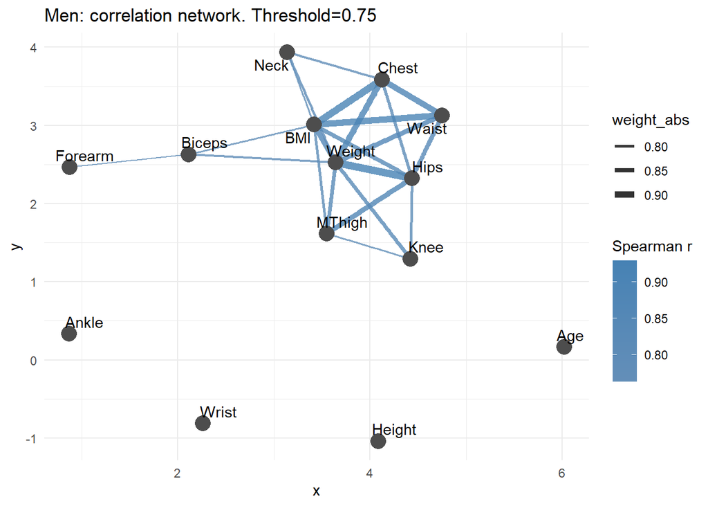

```r
correlation_network(men[,c("Weight", "Height", "BMI", "Age", "Neck", "Chest", "Biceps", "Hips", "Waist", "Forearm", "MThigh", "Wrist", "Knee", "Ankle")], threshold = 0.75, title = "Men: correlation network. Threshold=0.75")
```